# 08_RL

**Reinforcement Learning**

By Prof. Seungchul Lee  
http://iai.postech.ac.kr/  
Industrial AI Lab at POSTECH

Source

- By David Silver's RL Course at UCL
- By Prof. Zico Kolter at CMU

Table of Contents

# 1. Reinforcement Learning

```python
%%html
<center><iframe src="https://www.youtube.com/embed/un-FhSC0HfY?rel=0"
width="560" height="315" frameborder="0" allowfullscreen></iframe></center>
```

[video not shown]

**Agent interaction with environment**

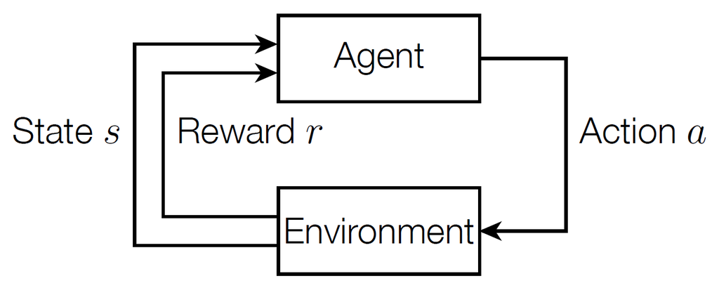

## 1.1. Markov Decision Processes

Recall a (discounted) Markov decision process is defined by:

$$M = (S,A,P,R)$$

- $S$: set of states
- $A$: set of actions
- $P$: $S \times A \times S \rightarrow [0,1]$: transition probability distribution $P(s' \mid s, a)$
- $R: S \rightarrow \mathbb{R}$: reward function, where $R(S)$ is reward for state $s$
- $\gamma$: discount factor
- Policy $\pi: S \rightarrow A$ is a mapping from states to actions

The RL twist: we do not know $P$ or $R$, or they are too big to enumerate (only have the ability to act in MDP, observe states and rewards)

Limitations of MDP

- Update equations require access to dynamics model $\Rightarrow$ sampling-based approximations
- Iteration over/storage for all states and actions: require small, discrete state-action space $\Rightarrow$ Q/V function fitting

## 1.2. Solving MDP

**(Policy evaluation)** Determine value of policy $\pi$

$$ \begin{align*} {v}_{\pi}(s) &= \mathbb{E} \left[ \sum_{t=0}^{\infty} \gamma^t R(s_t) \mid s_0 = s \right] \\ &= R(s) + \gamma \sum_{s' \in S}P \left(s' \mid s,\pi(s) \right) {v}_{\pi}\left(s'\right) \end{align*} $$

accomplished via the iteration (similar to a value iteration, but for a fixed policy)

$${v}_{\pi}(s) \; \leftarrow \; R(s) + \gamma \sum_{s' \in S}P \left(s' \mid s,\pi(s) \right) v_{\pi}\left(s'\right), \quad \forall s \in S$$

**(Value iteration)** Determine value of optimal policy

$$ {v_*}(s) = R(s) + \gamma \sum_{s' \in S}P(s' \mid s,a) {v_*}\left(s'\right) $$

accomplished via value iteration:

$$ v(s) \leftarrow R(s) + \gamma \max_{a \in A} \sum_{s' \in S}P\left(s' \mid s,a\right) v\left(s'\right), \quad \forall s \in S $$

Optimal policy $\pi_*$ is then $$\pi_*(s) = \arg \max_{a \in A} \sum_{s' \in S}P\left(s' \mid s,a\right) v_*\left(s'\right)$$

**How can we compute these quantities when $P$ and $R$ are unknown?**

- model-based RL
- model-free RL

## 1.3. Overview of RL

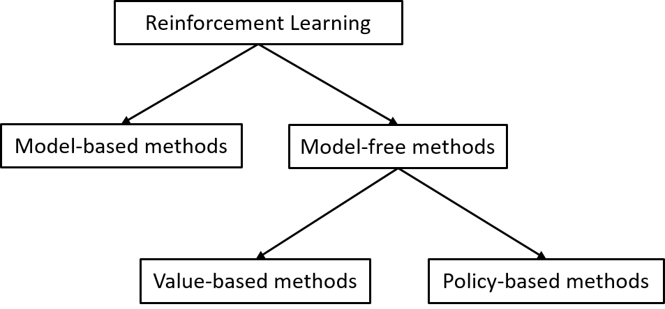

# 2. Model-based RL

A simple approach: just estimate the MDP from data (known as Monte Carlo method)

- Agent acts in the work (according to some policy), observes episodes of experience

$$s_1, r_1, a_1, s_2,r_2,a_2, \cdots, s_m, r_m, a_m$$

- We form the empirical estimate of the MDP via the counts

$$ \begin{align*} \hat{P}\left(s' \mid s,a\right) &= \frac{\sum_{i=1}^{m-1} \mathbf{1}\left\{s_i = s, a_i = a, s_{i+1} = s'\right\} }{\sum_{i=1}^{m-1} \mathbf{1}\{s_i = s, a_i = a\}}\\ \\ \hat{R}(s) &= \frac{ \sum_{i=1}^{m-1} \mathbf{1}\{s_i = s \} r_i} {\sum_{i=1}^{m-1} \mathbf{1}\{s_i = s\}} \end{align*} $$

Now solve the MDP $(S,A,\hat{P}, \hat{R})$

- Will converge to correct MDP (and hence correct value function/policy) given enough samples of each state
- How can we ensure we get the "right" samples? (a challenging problem for all methods we present here)
- Advantages (informally): makes "efficient" use of data
- Disadvantages: requires we build the actual MDP models, not much help if state space is too large

# 3. Model-free RL

- Temporal difference methods (TD, SARSA, Q-learning): directly learn value function $v_{\pi}$ or $v_*$
- Direct policy search: directly learn optimal policy $\pi_*$

## 3.1. Temporal Difference (TD) Methods

Let's consider computing the value function for a fixed policy via the iteration

$$ v_{\pi}(s) \; \leftarrow \; R(s) + \gamma \sum_{s' \in S}P\left(s' \mid s,\pi(s) \right) \, v_{\pi}\left(s'\right), \quad \forall s \in S $$

Suppose we are in some state $s_t$, receive reward $r_t$, take action $a_t = \pi(s_t)$ and end up in state $s_{t+1}$

We cannot update $v_{\pi}$ for all $s \in S$, but can we update just for $s_t$?

$$ v_{\pi}(s_t) \; \leftarrow \; r_t + \gamma \sum_{s' \in S}P\left(s' \mid s,a_t \right) v_{\pi}\left(s'\right) $$

... No, because we still do not know $P\left(s' \mid s,a_t \right)$ for all $s' \in S$

But, $s_{t+1}$ is a sample from the distribution $P(s' \mid s_t,a_t)$, so we could perform the update

$$ v_{\pi}(s_t) \; \leftarrow \; r_t + \gamma v_{\pi}(s_{t+1}) $$

- It is too "harsh" assignment if we assume that $s_{t+1}$ is the only possible next state;
- Instead "smooth" the update using some $\alpha < 1$

$$ v_{\pi}(s_t) \; \leftarrow \; (1-\alpha)\, \left( v_{\pi}(s_{t}) \right) + \alpha \,\left( r_t + \gamma v_{\pi}(s_{t+1}) \right)$$

This is the **temporal difference (TD)** algorithm. Its mathematical background will be briefly discussed later.

## 3.2. Issue with traditional TD algorithms

TD lets us learn the value function of a policy $\pi$ directly, without ever constructing the MDP.

But is this really that helpful?

Consider trying to execute greedy policy with respect to estimated $v_{\pi}$

$$\pi'(s) = \arg \max_{a \in A} \sum_{s' \in S}P\left(s' \mid s,a \right) v_{\pi}\left(s'\right)$$

We need a model $P \left(s' \mid s,a \right)$ anyway.

# 4. Entering the Q function

$Q$ function (for MDPs in general) are like value functions but defined over **state-action pairs**

$$ \begin{align*} Q_{\pi}(s,a) &= R(s) + \sum_{s' \in S} P\left(s' \mid s,a\right) Q_{\pi}\left(s',\pi\left(s'\right)\right) \\ \\ \\ Q_*(s,a) &= R(s) + \sum_{s' \in S} P\left(s' \mid s,a\right) \max_{a'}Q_* \left(s',a'\right) \\ \\ &= R(s) + \sum_{s' \in S} P\left(s' \mid s,a\right) v_*\left(s'\right) \end{align*} $$

i.e., $Q$ function is a value of starting state $s$, taking action $a$, and then acting according to $\pi$ (or optimally for $Q_*$)

We can easily construct analogues of value iteration or policy evaluation to construct $Q$ functions directly given an MDP.

Optimal policy

$$ \begin{align*} \pi_*(s) &= \arg \max_a \sum_{s'} P\left(s' \mid s, a \right) v_*\left(s'\right) \quad \text{or}\\ \\ \pi_*(s) &= \arg \max_a Q_*(s,a) \quad \text{without knowing dynamics} \end{align*} $$

## 4.1. SARSA and Q-learning

$Q$ function leads to new TD-like methods.

As with TD, observe state $s$, reward $r$, take action $a$ (but not necessarily $a = \pi(s)$), observe next sate $s'$

- SARSA: estimate $Q_{\pi}(s,a)$ for expectation

$${Q}_{\pi}(s,a) \leftarrow (1-\alpha) \left( {Q}_{\pi}(s,a) \right) + \alpha \left( r_t + \gamma {Q}_{\pi}\left(s',\pi \left(s'\right)\right) \right)$$

- $Q$-learning: estimate $Q_*(s,a)$ for optimality

$${Q}_*(s,a) \leftarrow (1-\alpha) \left( {Q}_*(s,a) \right) + \alpha \left( r_t + \gamma \max_{a'}{Q}_*\left(s',a'\right) \right)$$

Again, these algorithms converge to true $Q_{\pi}, Q_*$ if all state-action pairs are seen frequently enough

Note: State–Action–Reward–State–Action (SARSA)

The advantage of this approach is that we can now select actions without a model of MDP

- SARSA, greedy policy with respect to $Q_{\pi}(s,a)$

$$ \pi'(s) = \arg \max_{a} {Q}_{\pi}(s,a)$$

- $Q$-learning, optimal policy

$$\pi^*(s) = \arg \max_{a} {Q}_*(s,a)$$

So with $Q$-learning, for instance, we can learn optimal policy without model of MDP.

## 4.2. Solving Q-Value

**Q-value iterations**

$$ \begin{align*} Q_{k+1}(s,a) &\;\leftarrow \; R(s) + \gamma \sum_{s'}P\left(s'\mid s,a\right) \max_{a} Q_{k}\left(s',a'\right) \\\\ &\; \leftarrow \; 1 \cdot R(s) + \gamma \sum_{s'}P\left(s'\mid s,a\right) \max_{a} Q_{k}\left(s',a'\right) \\\\ &\; \leftarrow \; \sum_{s'}P\left(s'\mid s,a\right) \cdot R(s) + \gamma \sum_{s' \in S}P\left(s'\mid s,a\right) \max_{a} Q_{k}\left(s',a'\right) \\\\ &\; \leftarrow \; \sum_{s'}P\left(s'\mid s,a\right) \left[ R(s) + \gamma \max_{a} Q_{k}\left(s',a'\right) \right] \\\\ Q_{k+1}(s,a) &\; \leftarrow \; \mathbb{E}_{s' \sim P\left(s'\mid s,a\right)} \left[ R(s) + \gamma \max_{a} Q_{k}\left(s',a'\right) \right] \qquad \text{Rewrite as expectation} \end{align*} $$

**Q-Learning Algorithm: replace expectation by samples**

1) For an state-action pair $(s,a)$, receive: $s' \sim P\left(s' \mid s,a\right)$

2) Consider your old estimate: $Q_k(s,a)$

3) Consider your new sample estimate:
$$\text{target}\left(s'\right) = R(s) + \gamma \max_{a'}Q_k{\left(s',a'\right)}$$

4) Incorporate the new estimate into a running average [Temporal Difference or learning incrementally]:
$$ \begin{align*} Q_{k+1}(s,a) \; \leftarrow &\; Q_k(s,a) + \alpha \; \left(\text{target}\left(s'\right) - Q_k(s,a) \right) \\ \; \leftarrow &\; (1-\alpha) \; Q_k(s,a) + \alpha \;\text{target}\left(s'\right) \\ \; \leftarrow &\; (1-\alpha) \; Q_k(s,a) + \alpha \left( R(s) + \gamma \max_{a'}{Q}_k\left(s',a'\right) \right) \end{align*}$$

## 4.3. How to Sample Actions (Exploration vs. Exploitation) ?

All the methods discussed so far had some condition like "assuming we visit each state enough"

A fundamental question: if we do not know the system dynamics, should we take exploratory actions that will give us more information, or exploit current knowledge to perform as best we can?

Issue is that bad initial estimates in the first few cases can drive policy into sub-optimal region, and never explore further.

- Choose random actions ? or
- Choose action that maximizes $Q_k(s,a)$ (i.e., greedily) ?
- $\varepsilon$-Greedy: choose random action with probability $\varepsilon$, otherwise choose action greedily

$$\pi(s) = \begin{cases} \max_{a \in A} Q_k(s,a) & \text{with probability } 1 - \varepsilon \\ \\ \text{random action} & \text{otherwise} \end{cases}$$

- Want to decrease $\varepsilon$ as we see more examples

Q-Learning Properties

- Amazing result: Q-learning converges to optimal policy if all state-action pairs seen frequently enough
- With Q-learning, we can learn optimal policy without model of MDP
- This is called off-policy learning

## 4.4. Q-Learning Algorithm

> Initialize $Q(s,a)$ arbitrarily
> Repeat (for each episode):
> $\quad$Initialize $s$
> $\quad$Repeat (for each step of episode):
> $\quad \quad$Choose $a$ from $s$ using policy derived from $Q$ (e.g., $\varepsilon$ greedy)
> $\quad \quad$Take action $a$, observe $r, s'$
> $\quad \quad$${Q}_*(s,a) \leftarrow (1-\alpha) \left( {Q}_*(s,a) \right) + \alpha \left( r_t + \gamma \max_{a'} {Q}_*\left(s',a'\right) \right)$
> $\quad \quad$$s \; \leftarrow \; s'$
> until $s$ is terminal

# 5. Q-Learning with Gym Environment

- Agent interaction with environment

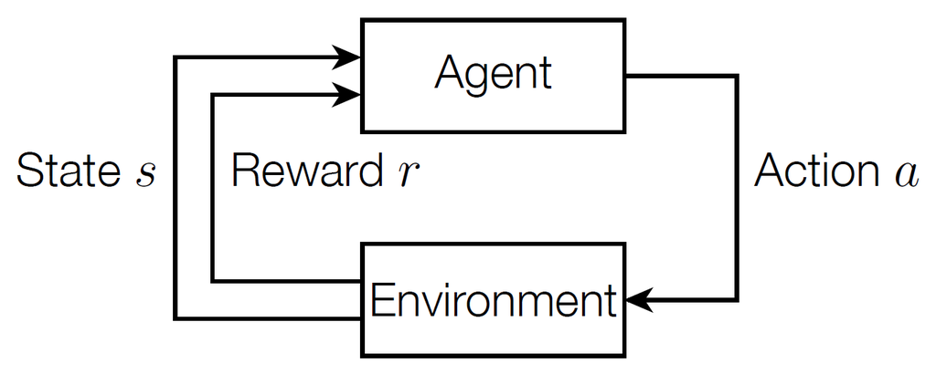

- [OpenAI Gym](https://gym.openai.com/)
  - A Python API for RL environments
  - A set of tools to measure agent performance
  - Read https://gym.openai.com/docs/
- Examples

[figure not shown]

```python
!pip install gym
```

```python
import numpy as np
import matplotlib.pyplot as plt
import tensorflow as tf

from IPython import display
from six.moves import cPickle

import gym
# import pyglet
%matplotlib inline
```

- A pole is attached by an un-actuated joint to a cart, which moves along a frictionless track. The system is controlled by applying a force of +1 or -1 to the cart. The pendulum starts upright, and the goal is to prevent it from falling over. A reward of +1 is provided for every timestep that the pole remains upright. The episode ends when the pole is more than 15 degrees from vertical, or the cart moves more than 2.4 units from the center.

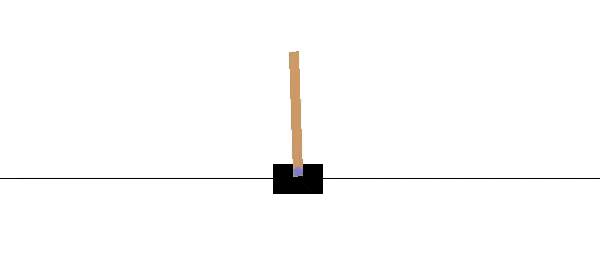

- Objective:
  - Balance a pole on top of a movable cart
- State:
  - [position, horizontal velocity, angle, angular speed]
- Action:
  - horizontal force applied on the cart (binary)
- Reward:
  - 1 at each time step if the pole is upright

```python
env = gym.make('CartPole-v0')
env.reset()
```

```
array([-0.03811126, -0.03486249, -0.0194325 ,  0.0400528 ])
```

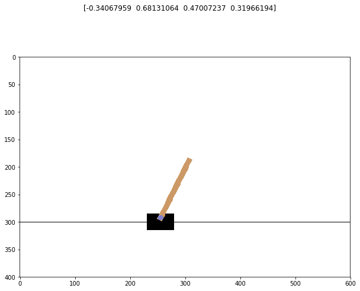

```python
fig = plt.figure(figsize = (10,8))
img = plt.imshow(env.render(mode = 'rgb_array')) # only call this once

for _ in range(40):
    img.set_data(env.render(mode = 'rgb_array')) # just update the data
    display.display(plt.gcf())
    display.clear_output(wait = True)
    action = env.action_space.sample()
    state,_,_,_ = env.step(action)
    fig.suptitle(state)
env.close()
```

$$Q(s,a) \leftarrow (1-\alpha )Q(s,a) + \alpha[r+\gamma \max_{a'}Q(s',a')]$$

Cartpole state = [pos, vel_pos, angle, vel_ang]

```python
print(env.observation_space.low)
print(env.observation_space.high)
```

```
[-4.8000002e+00 -3.4028235e+38 -4.1887903e-01 -3.4028235e+38]
[4.8000002e+00 3.4028235e+38 4.1887903e-01 3.4028235e+38]
```

```python
n_actions = env.action_space.n
print(n_actions)
```

```
2
```

```python
n_bins_pos = 10
n_bins_vel = 5
n_bins_ang = 10
n_bins_anv = 5
```

Initialize tabular $Q(s,a)$

```python
Q_table = np.random.uniform(0, 1, (n_bins_pos*n_bins_vel*n_bins_ang*n_bins_anv, n_actions))
```

```python
def cal_idx_state(state):
    pos, vel, ang, anv = state

    idx_pos = np.where(np.histogram(np.clip(pos,-2,2), bins = n_bins_pos, range = (-2,2))[0] == 1)[0][0]
    idx_vel = np.where(np.histogram(np.clip(vel,-2,2), bins = n_bins_vel, range = (-2,2))[0] == 1)[0][0]
    idx_ang = np.where(np.histogram(np.clip(ang,-0.418,0.418), bins = n_bins_ang, range = (-0.418,0.418))[0] == 1)[0][0]
    idx_anv = np.where(np.histogram(np.clip(anv,-2,2), bins = n_bins_anv, range = (-2,2))[0] == 1)[0][0]

    idx_state = (n_bins_vel*n_bins_ang*n_bins_anv)*idx_pos + (n_bins_ang*n_bins_anv)*idx_vel + (n_bins_anv)*idx_ang  + idx_anv

    return idx_state
```

```python
LR = 0.5
gamma = 0.99
```

- $\varepsilon$-Greedy: choose random action with probability $\varepsilon$, otherwise choose action greedily

$$\pi(s) = \begin{cases} \max_{a \in A} Q_k(s,a) & \text{with probability } 1 - \varepsilon \\ \\ \text{random action} & \text{otherwise} \end{cases}$$

- Want to decrease $\varepsilon$ as we see more examples

```python
env = gym.make('CartPole-v0')
state = env.reset()

frame = 0
episode = 0
complete_episodes = 0

while True:

    idx_state = cal_idx_state(state)

    # Exploration vs. Exploitation
    epsilon = 0.5 * (1 / (episode + 1))
    if np.random.random(1)[0] < epsilon:
        action = np.random.randint(2)
    else:
        action = np.argmax(Q_table[idx_state])

    new_state, _, done, _ = env.step(action)

    if done:
        if frame >= 199:
            reward = 1
            complete_episodes += 1
        else:
            reward = -1
            complete_episodes = 0

        frame = 0
        new_state = env.reset()
        episode += 1

    else:
        reward = 0

    if complete_episodes >= 10:
        print('Complete!')
        break

    new_idx_state = cal_idx_state(new_state)

    # Temporal Difference Update
    Q_table[idx_state, action] = (1-LR)*Q_table[idx_state, action] + LR*(reward + gamma*np.max(Q_table[new_idx_state,:]))

    state = new_state

    frame += 1

env.close()
```

```
Complete!
```

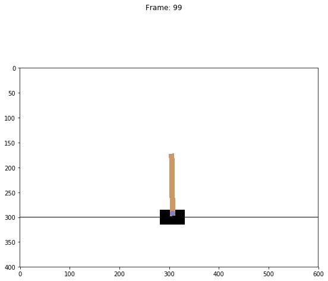

```python
frame = 0
episode = 0
complete_episodes = 0

fig = plt.figure(figsize = (9,8))
img = plt.imshow(env.render(mode = 'rgb_array'))

for _ in range(100):
    img.set_data(env.render(mode = 'rgb_array'))
    display.display(plt.gcf())
    display.clear_output(wait = True)

    idx_state = cal_idx_state(state)
    action = np.argmax(Q_table[idx_state])
    new_state, _, done, _ = env.step(action)

    if abs(state[0]) > 2.7 or abs(state[2]) > 0.45:
        frame = 0
        new_state = env.reset()

    state = new_state
    fig.suptitle('Frame: {}'.format(frame))
    frame += 1

env.close()
```

# 6. Other Tutorials

```python
%%html
<center><iframe src="https://www.youtube.com/embed/JgvyzIkgxF0?rel=0"
width="560" height="315" frameborder="0" allowfullscreen></iframe></center>
```

[video not shown]

**Stanford Univ. by Serena Yeung**

```python
%%html
<center><iframe src="https://www.youtube.com/embed/lvoHnicueoE?rel=0"
width="560" height="315" frameborder="0" allowfullscreen></iframe></center>
```

[video not shown]

**MIT**

```python
%%html
<center><iframe src="https://www.youtube.com/embed/xWe58WGWmlk?rel=0"
width="560" height="315" frameborder="0" allowfullscreen></iframe></center>
```

[video not shown]

```python
%%html
<center><iframe src="https://www.youtube.com/embed/s5qqjyGiBdc?rel=0"
width="560" height="315" frameborder="0" allowfullscreen></iframe></center>
```

[video not shown]

**David Silver's Lecture (DeepMind)**

- UCL homepage for slides (http://www0.cs.ucl.ac.uk/staff/d.silver/web/Teaching.html)
- DeepMind for RL videos (https://www.youtube.com/watch?v=2pWv7GOvuf0)
- An Introduction to Reinforcement Learning, Sutton and Barto pdf

```python
%%html
<center><iframe src="https://www.youtube.com/embed/2pWv7GOvuf0?rel=0"
width="560" height="315" frameborder="0" allowfullscreen></iframe></center>
```

[video not shown]

```python
%%javascript
$.getScript('https://kmahelona.github.io/ipython_notebook_goodies/ipython_notebook_toc.js')
```